# FUNCIONES Y SUS LÍMITES

El cálculo es muy diferente de las matemáticas que has estudiado hasta hoy, porque tiene que ver con cambios. En esta sección estudiaremos el comportamiento en cambio de funciones y sus límites.

## Funciones y su representación.

Las funciones surgen cuando una cantidad depende de otra. Consideremos algunos ejemplos.

#### Ejemplo A

El área de un círculo depende del radio del mismo: $$ A = \pi r^2 $$

```python
def area_circulo(radio):
    return 3.14159*radio^2

print(area_circulo(2.5267490372))
```

```
20.0573578810604
```

#### Ejemplo B

La población humana (en todo el mundo) $P$ depende del tiempo $t$. En la siguiente tabla, se muestra el año y la población en milliones correspondiente:

```python
poblacion = [
    [1900, 1650],
    [1910, 1750],
    [1920, 1860],
    [1930, 2070],
    [1940, 2300],
    [1950, 2560],
    [1960, 3040],
    [1970, 3710],
    [1980, 4450],
    [1990, 5280],
    [2000, 6080],
    [2010, 6870]
            ]
```

A partir de esta tabla, podemos crear una función punto a punto:

```python
def P(t):
    for dato in poblacion:
        if t==dato[0]:
            return dato[1]

print(P(1950))
```

```
2560
```

#### Ejemplo C

El costo $C$ de enviar un paquete depende del peso $w$. Por ejemplo, supongamos que los precio están dados por las siguiente reglas:

- Menor o igual a 10 kgs: Costo fijo de \$150 más \$10 por kilogramo
- Mayor a 10 kgs: \$25 por kilogramo
- La capacidad máxima del envíoi es 20 kgs

```python
def C(w):
    if w<0:
        return "¿Seguro que estás enviando algo?"
    elif w<=10:
        return 150 + 10*w
    elif w<=20:
        return 25*w
    else:
        return "¡Excediste la capacidad!"
```

```python
import numpy as np
import matplotlib.pyplot as plt

x = np.arange(0,20,0.01)
C = np.vectorize(C)
y = C(x)

plt.plot(x,y)
plt.show()
```

[output not shown]

#### Ejemplo D

La aceleracion vertical $a$ del suelo en un terremoto

[figure not shown]

```python
def a(t):
    return np.sin(t)*np.random.normal()
```

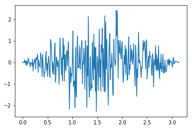

```python
x = np.arange(0,np.pi,0.01)
a = np.vectorize(a)
y = a(x)

plt.plot(x,y)
```

Una **función** $f$ es una regla que asigna a cada elemento $x$ de un conjunto $D$ un elemento $f(x)$ de un conjunto $E$.

Al conjunto $D$ se le llama **dominio**, mientras que a $E$ se le llama **contradominio**.

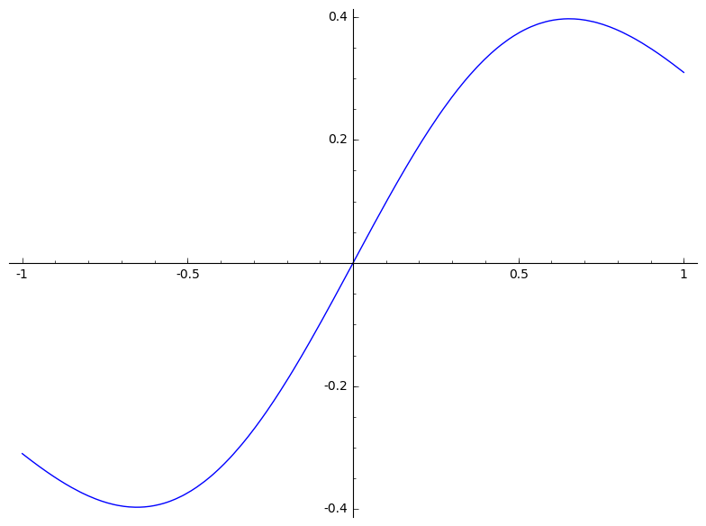

```python
x = var("x")
f(x) = exp(-x^2)*sin(x)
grafica = plot(f)
show(grafica)
```

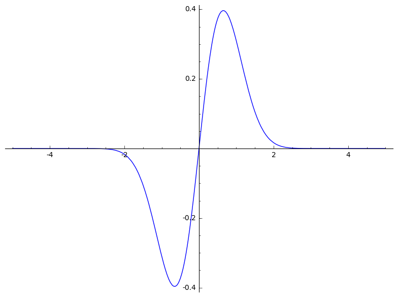

```python
grafica = plot(f, (x,-5,5))
show(grafica)
```

### Representación de funciones

#### Ejercicio

Encuentre el dominio de cada función:

- $f(x)=\sqrt{x+2}$
- $g(x)=\dfrac{1}{x^2-x}$

#### Ejemplo

Determina si la ecuación $x^2-y^2=1$ define una función $y=f(x)$.

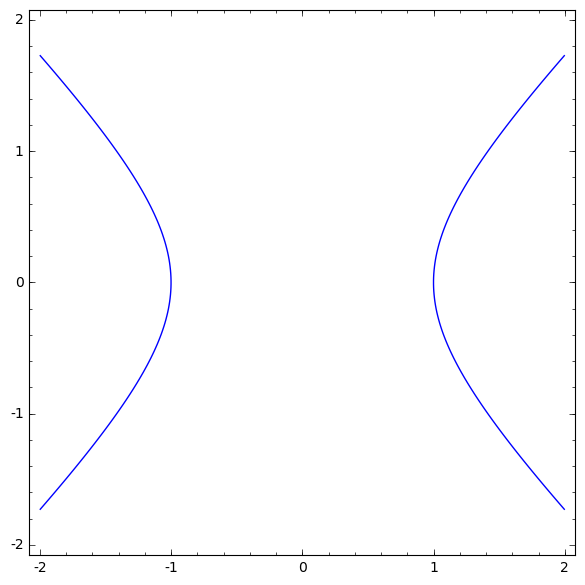

```python
x,y = var("x,y")
ecuacion = x^2-y^2==1
grafica = implicit_plot(ecuacion, (x,-2,2), (y,-2,2))
show(grafica)
```

#### Ejemplo

Determina si la ecuación $(x-1)^2=4(y-2)$ define una función $y=f(x)$.

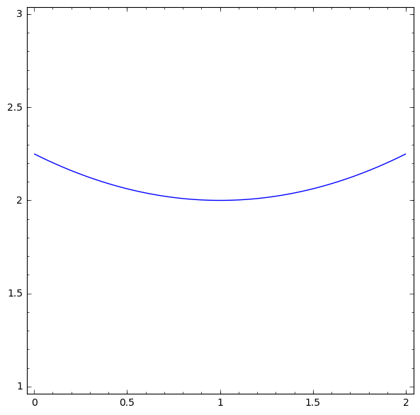

```python
x,y = var("x,y")
ecuacion = (x-1)^2==4*(y-2)
grafica = implicit_plot(ecuacion, (x,0,2), (y,1,3))
show(grafica)
```

#### Ejemplo

Determina si la gráfica de las ecuaciones paramétricas: $$ x = 10t, y = 50+5t-\dfrac{1}{2}(9.8)t^2$$ define una función $y=f(x)$.

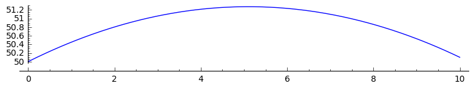

```python
t = var("t")
x(t) = 10*t
y(t) = 50+5*t-(1/2)*(9.8)*t^2
grafica = parametric_plot((x(t),y(t)), (t,0,1))

show(grafica)
```

#### Ejercicio de exploración

Las funciones anteriores representan la posición de un proyectil en función del tiempo. Determina gráficamente:

- la distancia a la que choca contra el suelo
- cuanto tiempo tarde en ocurrir esto
- la altura máxima y el tiempo en que se alcanza

¿Puedes determinar cuál es la función $y=f(x)$?

#### Ejercicio de exploración

Muchas relaciones fundamentales en matemáticas y física no se pueden expresar como funciones. Aún así se puede definir el dominio de una relación. Averigua en internet como es que se hace esto y determinalo gráficamente para la relación

$$ \dfrac{(x-2)^2}{9} + \dfrac{(y-3)^2}{4} = 1 $$.

*¿Cuál es el intervalo minimal en el eje $y$ que necesitas para graficar completamente la relación?*

### Funciones representadas a trozos

#### Ejemplo

Una función $f$ esta definida por $$f(x)= \begin{cases} 1-x & x \leq 1\\ x^2 & x>1 \end{cases} $$

Evaluar $f(0), f(1), f(2)$ y graficar la función.

```python
def f(x):
    if x<=1:
        return 1-x
    else:
        return x**2
```

```python
import numpy as np
f = np.vectorize(f)
x = [0,1,2]
y = f(x)
print(y)
```

```
[1 0 4]
```

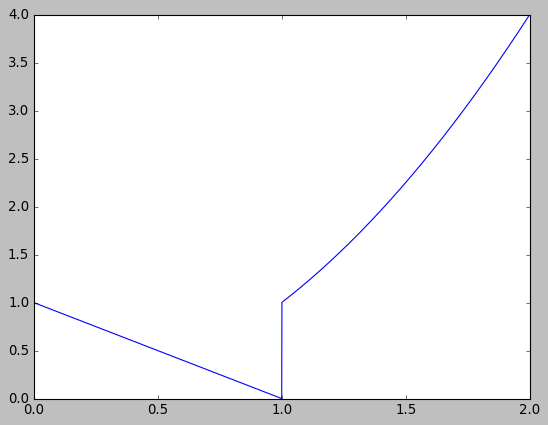

```python
import matplotlib.pyplot as plt

x = np.arange(0,2,0.001)
y = f(x)

plt.plot(x,y)
plt.show()
```

#### Ejercicio (Valor absoluto)

- Investiga como se define la función *valor absoluto*
- Implementala en `Python`
- Evaluala en el arreglo $x=-1,0,1$
- Traza la gráfica

### Simetría

Si una función $f(x)$ satisface la relación $f(x)=f(-x)$ en su dominio, diremos que la función es **par**. Su gráfica es simétrica respecto al eje $y$.

#### Ejemplo

$$ f(x) = x^2 $$

```python
x = var("x")
f(x) = x^2
show(f(-x))
```

$$\newcommand{\Bold}[1]{\mathbf{#1}}x^{2}$$

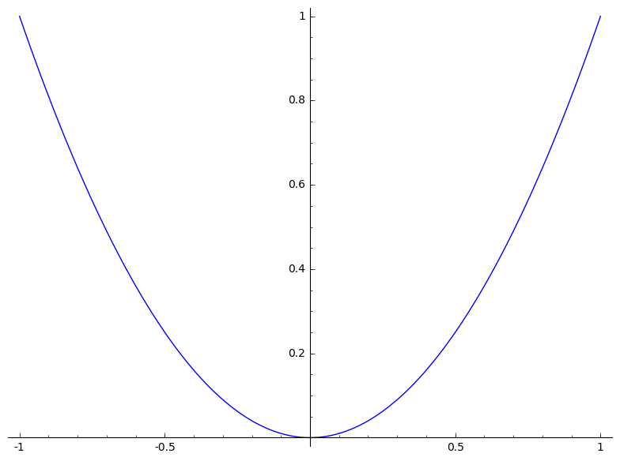

```python
plot(f)
```

#### Ejemplo

$$ g(x) = cos(x) $$

```python
x = var("x")
g(x) = cos(x)
show(g(-x).simplify())
```

$$\newcommand{\Bold}[1]{\mathbf{#1}}\cos\left(x\right)$$

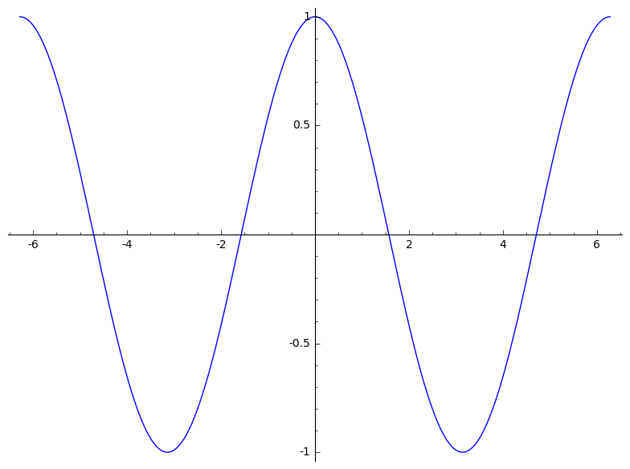

```python
plot(g, (x,-2*pi, 2*pi))
```

Si una función $f(x)$ satisface la relación $f(-x)=-f(x)$ en su dominio, diremos que la función es **impar**. Su gráfica es simétrica respecto al origen.

#### Ejemplo 4

$$f(x) = x^3$$

```python
x = var("x")
f(x) = x^3
show(f(-x).simplify())
```

$$\newcommand{\Bold}[1]{\mathbf{#1}}-x^{3}$$

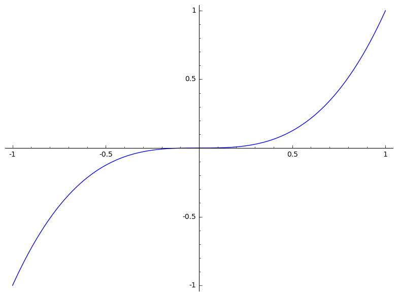

```python
plot(f)
```

#### Ejemplo

$$g(x) = \sin(x)$$

```python
x = var("x")
g(x) = sin(x)
show(g(-x).simplify())
```

$$\newcommand{\Bold}[1]{\mathbf{#1}}-\sin\left(x\right)$$

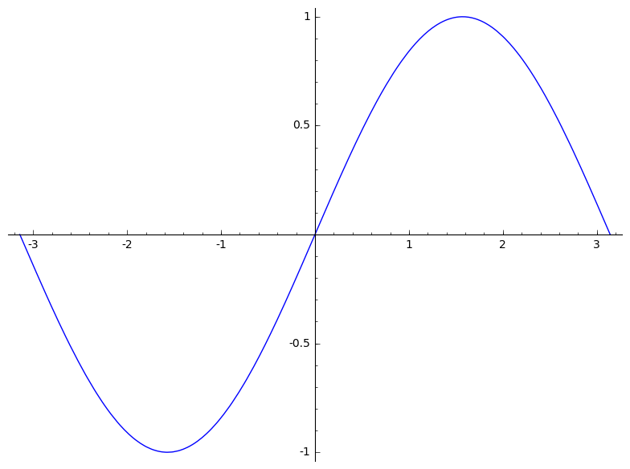

```python
plot(g, (x,-pi,pi))
```

#### Ejercicio

Determina si las siguiente funciones son pares, impares o ninguna:

- $f(x)=x^5+x$
- $g(x)=1-x^4$
- $h(x)=2x-x^2$

#### Funciones crecientes y decrecientes

Una función $f$ es **creciente** en un intervalo $I$ si $$f(x_0) < f(x_1)$$ siempre que $x_1 < x_2$.

**Observación** El intervalo es muy importante para determinar si la función es creciente o no. Consideremos la función $f(x)=x^2$ en los intervalos

```python
x = var("x")
f(x) = x^2
```

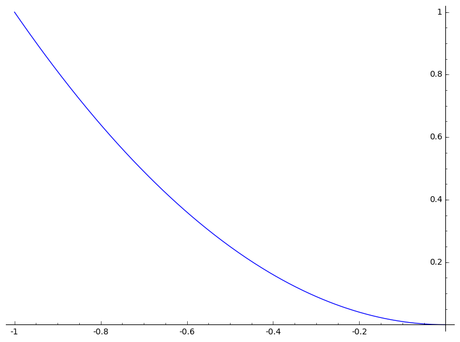

```python
plot(f, (x,-1,0))
```

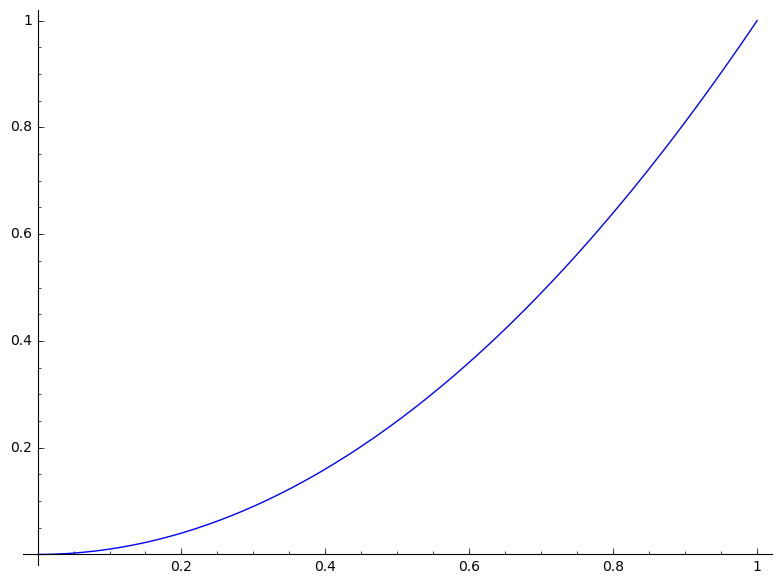

```python
plot(f, (x,0,1))
```

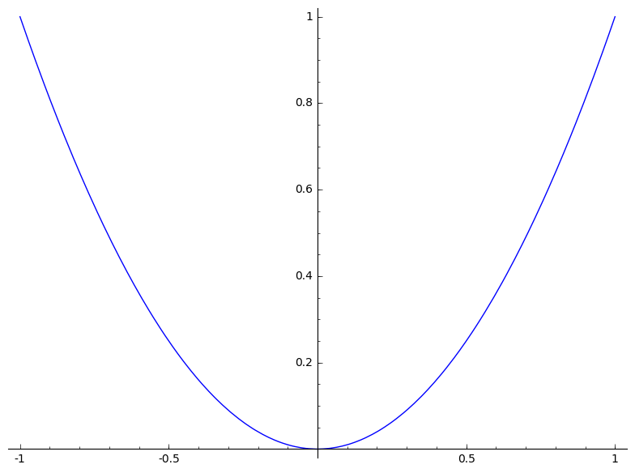

```python
plot(f, (x,-1,1))
```